# 04 - Elegir un entorno de desarrollo

François Rebaudo, IRD francois.rebaudo@ird.fr

Marzo 2019 ; PUCE-Quito-Ecuador http://myrbooksp.netlify.com/ CC BY-NC-ND 3.0

[figure not shown]

[figure not shown]

# RStudio

## RStudio

[figure not shown]

https://www.rstudio.com/

## RStudio

[figure not shown]

http://myrbooksp.netlify.com/ide

## RStudio

pros:

- Windows / Mac OSX / Linux
- desarrollo de paquetes
- muchas opciones de R
- solo para R

cons:

- solo para R
- pesado (lento)

# Notepad++ con Npp2R

## Notepad++ con Npp2R

[figure not shown]

https://notepad-plus-plus.org/

## Notepad++ con Npp2R

[figure not shown]

http://myrbooksp.netlify.com/ide

## Notepad++ con Npp2R

pros:

- rápido
- cualquier lenguaje de programación

cons:

- solo para Windows

# Geany

## Geany

[figure not shown]

https://www.geany.org/

## Geany

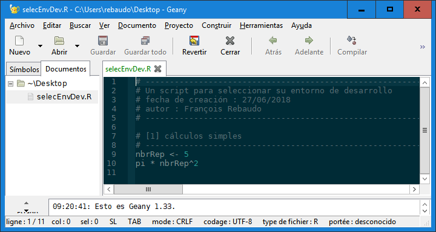

http://myrbooksp.netlify.com/ide

## Geany

pros:

- bastante rápido
- muchas opciones
- cualquier lenguaje de programación

cons:

- funciona con Windows y Mac OSX pero desarrollado para Linux

# Otras soluciones

## Otras soluciones

[figure not shown]

[figure not shown]

…

## RStudio

Vamos a usar RStudio para que todos tengamos el mismo editor. Todos nuestros scripts funcionan con **TODOS** los editores: **UN SCRIPT DEBE FUNCIONAR CON CUALQUIER EDITOR DE TEXTO** (reproducibilidad).

# SIGUIENTE

# 04 - Elegir un entorno de desarrollo

François Rebaudo, IRD francois.rebaudo@ird.fr

Marzo 2019 ; PUCE-Quito-Ecuador http://myrbooksp.netlify.com/

[figure not shown]

[figure not shown]

# RStudio

## RStudio

[figure not shown]

https://www.rstudio.com/

## RStudio

[figure not shown]

http://myrbooksp.netlify.com/ide

## RStudio

pros:

- Windows / Mac OSX / Linux
- desarrollo de paquetes
- muchas opciones de R
- solo para R

cons:

- solo para R
- pesado (lento)

# Notepad++ con Npp2R

## Notepad++ con Npp2R

[figure not shown]

https://notepad-plus-plus.org/

## Notepad++ con Npp2R

[figure not shown]

http://myrbooksp.netlify.com/ide

## Notepad++ con Npp2R

pros:

- rápido
- cualquier lenguaje de programación

cons:

- solo para Windows

# Geany

## Geany

[figure not shown]

https://www.geany.org/

## Geany

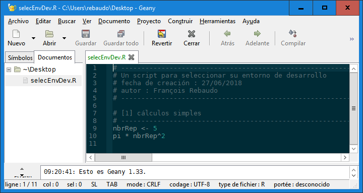

http://myrbooksp.netlify.com/ide

## Geany

pros:

- bastante rápido
- muchas opciones
- cualquier lenguaje de programación

cons:

- funciona con Windows y Mac OSX pero desarrollado para Linux

# Otras soluciones

## Otras soluciones

[figure not shown]

[figure not shown]

…

## RStudio

Vamos a usar RStudio para que todos tengamos el mismo editor. Todos nuestros scripts funcionan con **TODOS** los editores: **UN SCRIPT DEBE FUNCIONAR CON CUALQUIER EDITOR DE TEXTO** (reproducibilidad).